# Project: No-Show Appointment Data Analysis

## Define:

- columns like `PatientId` & `AppointmentID` will not be having that effect during my analysis. ## solution:
- Drop these columns using `.drop()`function. ## Code:

```python
patients_info.drop(['PatientId','AppointmentID'], axis=1, inplace=True)
```

```python
# check:
patients_info.shape
patients_info.info()
```

```
<class 'pandas.core.frame.DataFrame'>
Int64Index: 110520 entries, 0 to 110526
Data columns (total 12 columns):
 #   Column          Non-Null Count   Dtype
---  ------          --------------   -----
 0   Gender          110520 non-null  object
 1   ScheduledDay    110520 non-null  datetime64[ns, UTC]
 2   AppointmentDay  110520 non-null  datetime64[ns, UTC]
 3   Age             110520 non-null  float64
 4   Neighbourhood   110520 non-null  object
 5   Scholarship     110520 non-null  int64
 6   Hipertension    110520 non-null  int64
 7   Diabetes        110520 non-null  int64
 8   Alcoholism      110520 non-null  int64
 9   Handcap         110520 non-null  int64
 10  SMS_received    110520 non-null  int64
 11  No-show         110520 non-null  object
dtypes: datetime64[ns, UTC](2), float64(1), int64(6), object(3)
memory usage: 11.0+ MB
```

## Define:

- there are duplicate values. ## solution:
- Drop these rows using `.drop_duplicates()`function. ## Code:

```python
# check how many duplicate values in our data frame.
sum(patients_info.duplicated())
```

```
634
```

```python
# drop in action.
patients_info.drop_duplicates(inplace= True)

#check
patients_info.shape
```

```
(109886, 12)
```

## Exploratory Data Analysis

- To make grab these rows easily, I am going to create masks for rows for people who came their doctor appointment & the others who did not show up.

```python
patients_info.columns
```

```
Index(['Gender', 'ScheduledDay', 'AppointmentDay', 'Age', 'Neighbourhood',
       'Scholarship', 'Hipertension', 'Diabetes', 'Alcoholism', 'Handcap',
       'SMS_received', 'No-show'],
      dtype='object')
```

```python
attendance=patients_info[patients_info['No-show'] =='No']
absence=patients_info[patients_info['No-show'] =='Yes']
```

```python
attendance.shape[0] , absence.shape[0]
```

```
(87790, 22096)
```

### Neighbourhood

### Where are the heighst number of people who show up from?

Let's take a look at the location of people who came to their appointments & who didn't.

```python
attendance.Neighbourhood.nunique()
```

```
80
```

I can know what is the location of the heighst number of people how show up.

```python
att_location= attendance.Neighbourhood.value_counts().head(15)
att_location
```

```
JARDIM CAMBURI       6187
MARIA ORTIZ          4584
RESISTÊNCIA          3502
JARDIM DA PENHA      3242
CENTRO               2615
SANTA MARTHA         2614
ITARARÉ              2568
TABUAZEIRO           2555
SANTO ANTÔNIO        2255
BONFIM               2213
JESUS DE NAZARETH    2157
JABOUR               2056
SANTO ANDRÉ          2052
CARATOÍRA            1958
SÃO PEDRO            1922
Name: Neighbourhood, dtype: int64
```

we can visualize this information using `bar chart`.

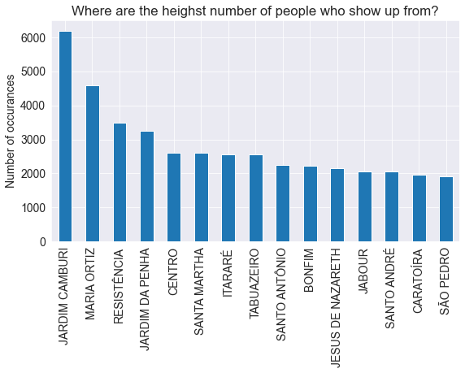

```python
att_location.plot(kind="bar")
plt.title('Where are the heighst number of people who show up from?')
plt.ylabel('Number of occurances');
```

lets make better visualisation using `seaborn`

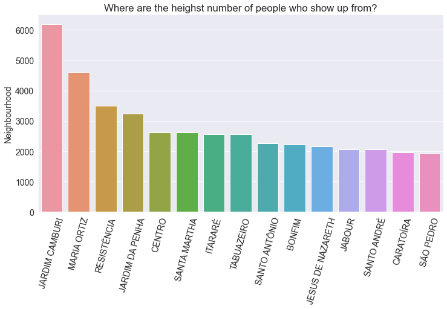

```python
plt.figure(figsize=(12,6))
plt.xticks(rotation=75)
plt.title('Where are the heighst number of people who show up from?')
sns.barplot(x=att_location.index, y=att_location);
```